# 15_optimize_run_swim

## 15_optimize_run_swim

#### Question

1. A lifeguard wants to save a struggling swimmer as soon as possible. The lifeguard can run along the beach at 2.4 m/s and swim at 1.8 m/s. The lifeguard will run $x$ meters and swim $\sqrt{(130-x)^2+10^2}$ meters.

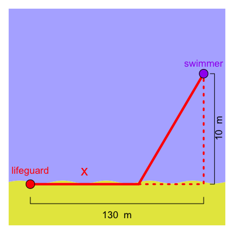

   Thus, the time is a function of $x$.

   $$t(x) ~=~ \frac{x}{2.4} + \frac{\sqrt{(130-x)^2+10^2}}{1.8}$$

   Find the value of $x$ (in meters) that minimizes the amount of time. The tolerance is $\pm 0.1$ meters.

#### Question

2. A lifeguard wants to save a struggling swimmer as soon as possible. The lifeguard can run along the beach at 2.1 m/s and swim at 1 m/s. The lifeguard will run $x$ meters and swim $\sqrt{(200-x)^2+60^2}$ meters.

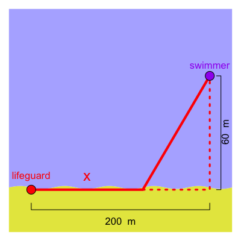

   Thus, the time is a function of $x$.

   $$t(x) ~=~ \frac{x}{2.1} + \frac{\sqrt{(200-x)^2+60^2}}{1}$$

   Find the value of $x$ (in meters) that minimizes the amount of time. The tolerance is $\pm 0.1$ meters.

#### Question

3. A lifeguard wants to save a struggling swimmer as soon as possible. The lifeguard can run along the beach at 2.8 m/s and swim at 1.6 m/s. The lifeguard will run $x$ meters and swim $\sqrt{(280-x)^2+10^2}$ meters.

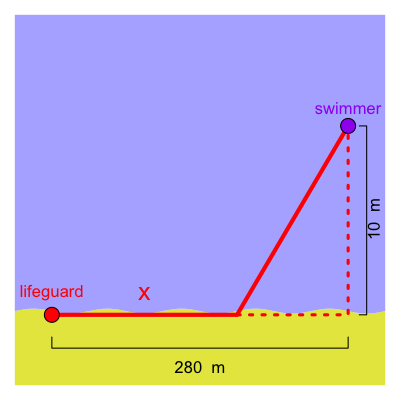

   Thus, the time is a function of $x$.

   $$t(x) ~=~ \frac{x}{2.8} + \frac{\sqrt{(280-x)^2+10^2}}{1.6}$$

   Find the value of $x$ (in meters) that minimizes the amount of time. The tolerance is $\pm 0.1$ meters.

#### Question

4. A lifeguard wants to save a struggling swimmer as soon as possible. The lifeguard can run along the beach at 4 m/s and swim at 1.2 m/s. The lifeguard will run $x$ meters and swim $\sqrt{(190-x)^2+60^2}$ meters.

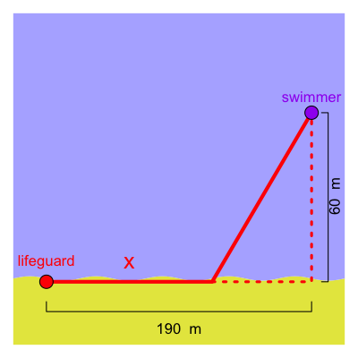

   Thus, the time is a function of $x$.

   $$t(x) ~=~ \frac{x}{4} + \frac{\sqrt{(190-x)^2+60^2}}{1.2}$$

   Find the value of $x$ (in meters) that minimizes the amount of time. The tolerance is $\pm 0.1$ meters.

#### Question

5. A lifeguard wants to save a struggling swimmer as soon as possible. The lifeguard can run along the beach at 2.4 m/s and swim at 1.5 m/s. The lifeguard will run $x$ meters and swim $\sqrt{(160-x)^2+10^2}$ meters.

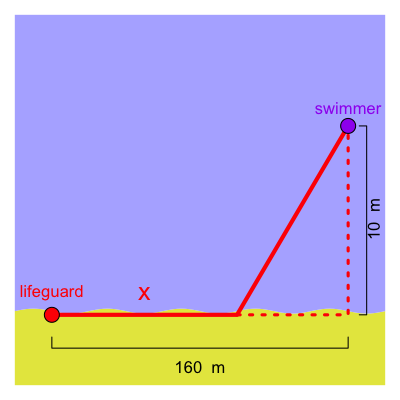

   Thus, the time is a function of $x$.

   $$t(x) ~=~ \frac{x}{2.4} + \frac{\sqrt{(160-x)^2+10^2}}{1.5}$$

   Find the value of $x$ (in meters) that minimizes the amount of time. The tolerance is $\pm 0.1$ meters.

#### Question

6. A lifeguard wants to save a struggling swimmer as soon as possible. The lifeguard can run along the beach at 2.8 m/s and swim at 0.8 m/s. The lifeguard will run $x$ meters and swim $\sqrt{(140-x)^2+10^2}$ meters.

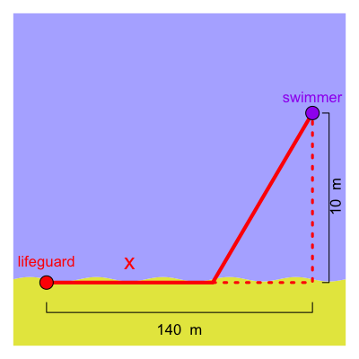

   Thus, the time is a function of $x$.

   $$t(x) ~=~ \frac{x}{2.8} + \frac{\sqrt{(140-x)^2+10^2}}{0.8}$$

   Find the value of $x$ (in meters) that minimizes the amount of time. The tolerance is $\pm 0.1$ meters.

#### Question

7. A lifeguard wants to save a struggling swimmer as soon as possible. The lifeguard can run along the beach at 2.7 m/s and swim at 1.3 m/s. The lifeguard will run $x$ meters and swim $\sqrt{(140-x)^2+50^2}$ meters.

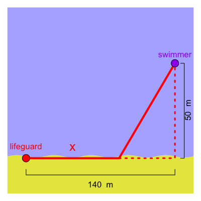

   Thus, the time is a function of $x$.

   $$t(x) ~=~ \frac{x}{2.7} + \frac{\sqrt{(140-x)^2+50^2}}{1.3}$$

   Find the value of $x$ (in meters) that minimizes the amount of time. The tolerance is $\pm 0.1$ meters.

#### Question

8. A lifeguard wants to save a struggling swimmer as soon as possible. The lifeguard can run along the beach at 3.6 m/s and swim at 0.9 m/s. The lifeguard will run $x$ meters and swim $\sqrt{(210-x)^2+10^2}$ meters.

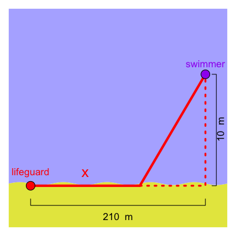

   Thus, the time is a function of $x$.

   $$t(x) ~=~ \frac{x}{3.6} + \frac{\sqrt{(210-x)^2+10^2}}{0.9}$$

   Find the value of $x$ (in meters) that minimizes the amount of time. The tolerance is $\pm 0.1$ meters.